### Chapter 6 Exercises

**1.**

**(a)** Best subset

**(b)** Best subset

**(c)**

i.True

ii.True

iii.False

iv.False

v.False

**2.**

**(a)** iii. Correct. The lasso is less flexible with l1 penalty, while it does improve the accuracy when its increase in bias is less than its decrease in variance.

**(b)** iii. Correct. The ridge is less flexible with l2 penalty, while it does improve the accuracy when its increase in bias is less than its decrease in variance.

**(c)** ii. Correct. To some extent, the nonlinear method is more flexible when its increase in variance is less than its decrease in bias.

**3.**

**(a)** iv. Correct. This is the Lasso Regression. S is thought as a budget (opposite from lambda). The model becomes more flexible with s increasing from 0, therefore the training RSS would decrease steadily.

**(b)** ii. Correct. Initially, the increase in bias is less than the decrease in variance. After a certain value of s, the increase in grows faster than decrease in variance, and the test RSS would increase.

**(c)** iii. Correct. The method becomes more flexible and the variance increase steadily.

**(d)** iv. Correct. With shrinkage, some parameters become zero and the bias will decrease steadily.

**(e)** v. Correct. The s only impacts on variance and bias.

**(b)** ii. Initially, the increase in bias is less than decrease in variance, resulting in decrease in test RSS. After a certain value of lambda, the increase in bias is larger than decrease in variance, and the test RSS increases.

**(c)** iv.

**(d)** iii.

**(e)** v.

**5.**

image:

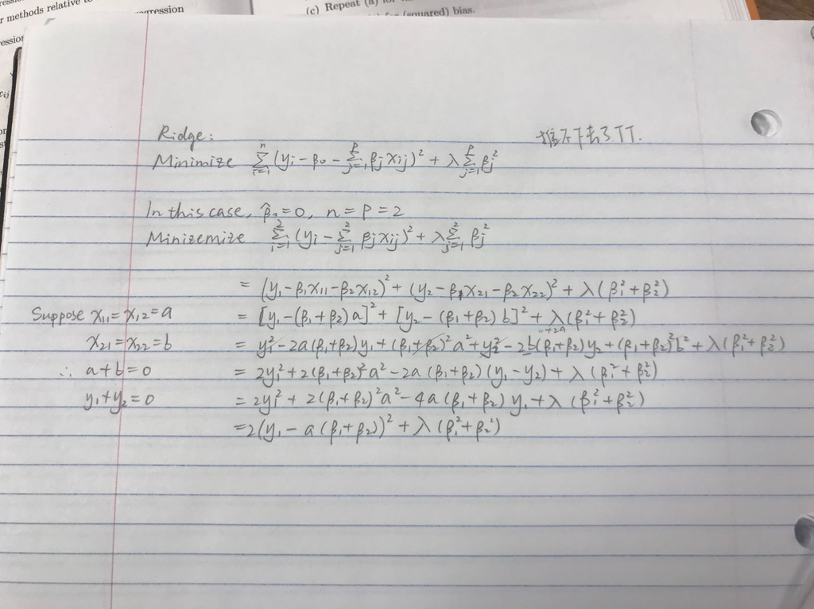

**6.** **(a)**

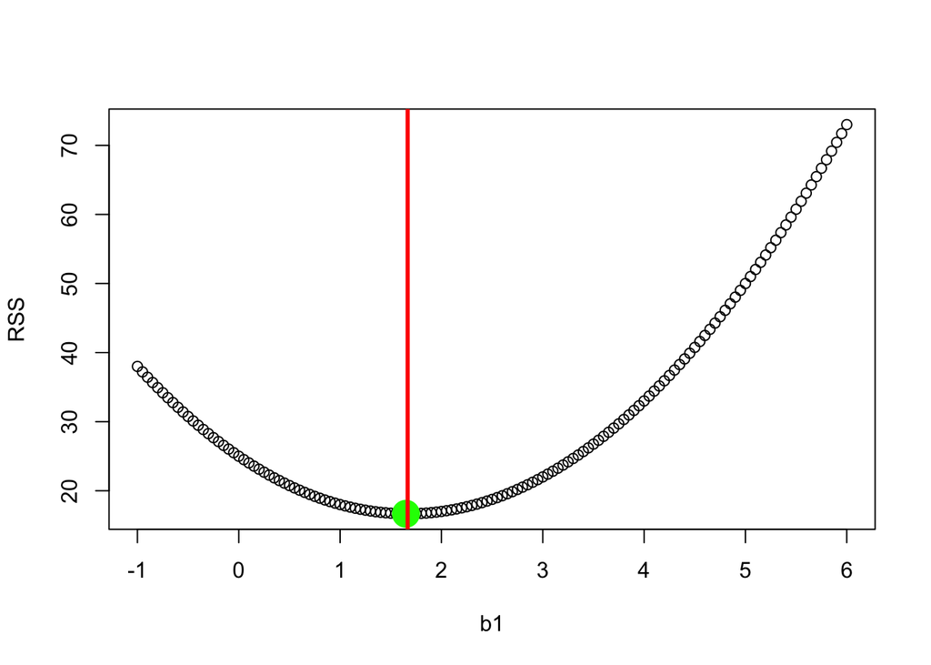

```r
y1=5
lambda=2
b1=seq(-1,6,0.05)
RSS=((y1-b1)^2)+lambda*(b1^2)
plot(b1,RSS)
points(b1[which.min(RSS)],RSS[which.min(RSS)],col="Green",cex=4,pch=20)
abline(v=y1/(1+lambda),col="red",lwd=3)
```

**(b)**

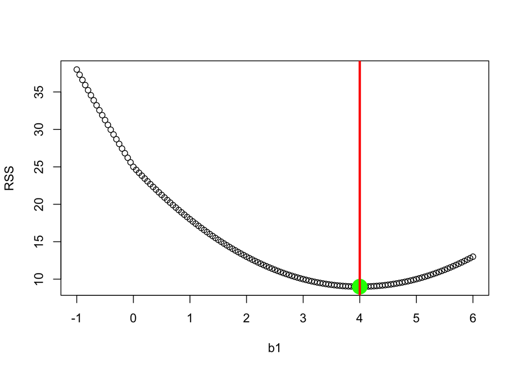

```r
y1=5
lamda=2
b1=seq(-1,6,0.05)
RSS=((y1-b1)^2)+lambda*abs(b1)
plot(b1,RSS)
points(b1[which.min(RSS)],RSS[which.min(RSS)],col="Green",cex=4,pch=20)
if (y1 > lambda/2) {
  beta=y1-lambda/2
}else if (y1 < lambda/2) {
  beta=y1+lambda/2
}else {
  beta = 0
}
abline(v=beta,col="red",lwd=3)
```

**8.**

**(a)**

```r
x = rnorm(100)
err = rnorm(100)
```

**(b)**

```r
b0=3
b1=5
b2=-5
b3=0.2
y = b0 + b1*x + b2*(x^2) + b3*(x^3) + err
```

**(c)**

```r
library(ISLR)
library(leaps)
all = data.frame(x,x^2,x^3,x^4,x^5,x^6,x^7,x^8,x^9,x^10,y)
regfit.full=regsubsets(y~., all)
summary(regfit.full)
```

```
## Subset selection object
## Call: regsubsets.formula(y ~ ., all)
## 10 Variables  (and intercept)
##      Forced in Forced out
## x        FALSE      FALSE
## x.2      FALSE      FALSE
## x.3      FALSE      FALSE
## x.4      FALSE      FALSE
## x.5      FALSE      FALSE
## x.6      FALSE      FALSE
## x.7      FALSE      FALSE
## x.8      FALSE      FALSE
## x.9      FALSE      FALSE
## x.10     FALSE      FALSE
## 1 subsets of each size up to 8
## Selection Algorithm: exhaustive
##          x   x.2 x.3 x.4 x.5 x.6 x.7 x.8 x.9 x.10
## 1  ( 1 ) " " "*" " " " " " " " " " " " " " " " "
## 2  ( 1 ) "*" "*" " " " " " " " " " " " " " " " "
## 3  ( 1 ) "*" "*" "*" " " " " " " " " " " " " " "
## 4  ( 1 ) "*" "*" " " " " " " " " "*" "*" " " " "
## 5  ( 1 ) "*" "*" "*" " " " " " " " " " " "*" "*"
## 6  ( 1 ) "*" "*" " " " " "*" "*" " " "*" " " "*"
## 7  ( 1 ) "*" "*" "*" "*" " " "*" " " "*" " " "*"
## 8  ( 1 ) "*" "*" " " "*" " " "*" "*" "*" "*" "*"
```

```r
regfit.full=regsubsets(y~.,data=all,nvmax=9)
reg.summary=summary(regfit.full)
par(mfrow=c(2,2))
plot(reg.summary$rss,xlab="Number of Variables",ylab="Rss",type="l")
plot(reg.summary$adjr2,xlab="Number of Variables",ylab="Adjusted RSq",type="l")
which.max(reg.summary$adjr2)
```

```
## [1] 4
```

```r
points(9,reg.summary$adjr2[9],col="red",cex=2,pch=20)
plot(reg.summary$cp,xlab="Number of Variables",ylab="Cp",type="l")
which.min(reg.summary$cp)
```

```
## [1] 3
```

```r
points(3,reg.summary$cp [3],col="red",cex=2,pch=20)
which.min(reg.summary$bic)
```

```
## [1] 3
```

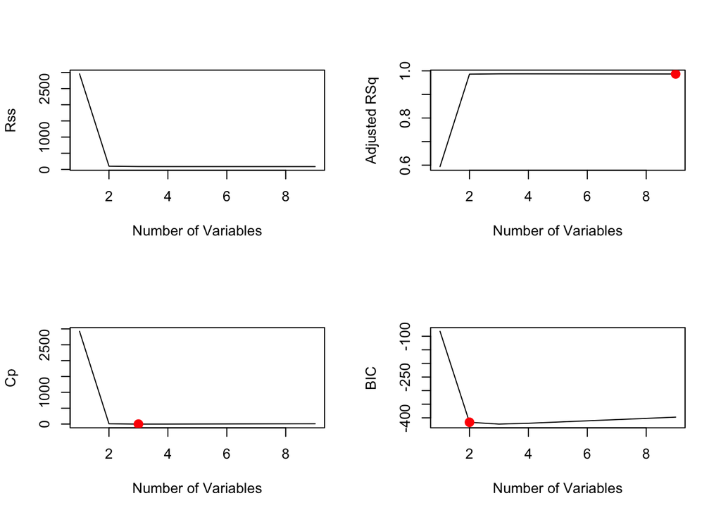

```r
plot(reg.summary$bic,xlab="Number of Variables",ylab="BIC",type="l")
points(2,reg.summary$bic[2],col="red",cex=2,pch=20)
```

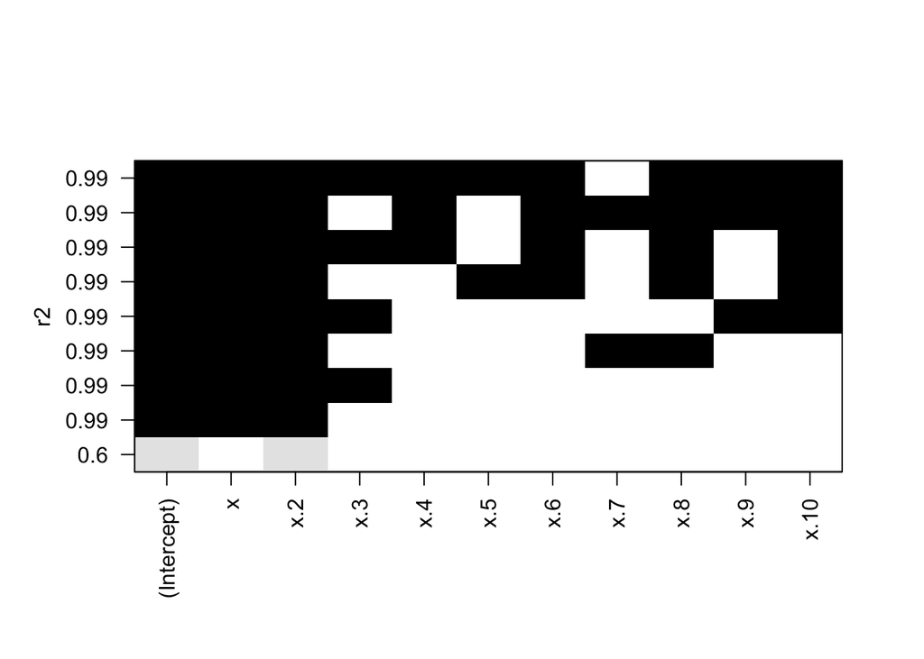

```r
par(mfrow=c(1,1))
plot(regfit.full,scale="r2")
```

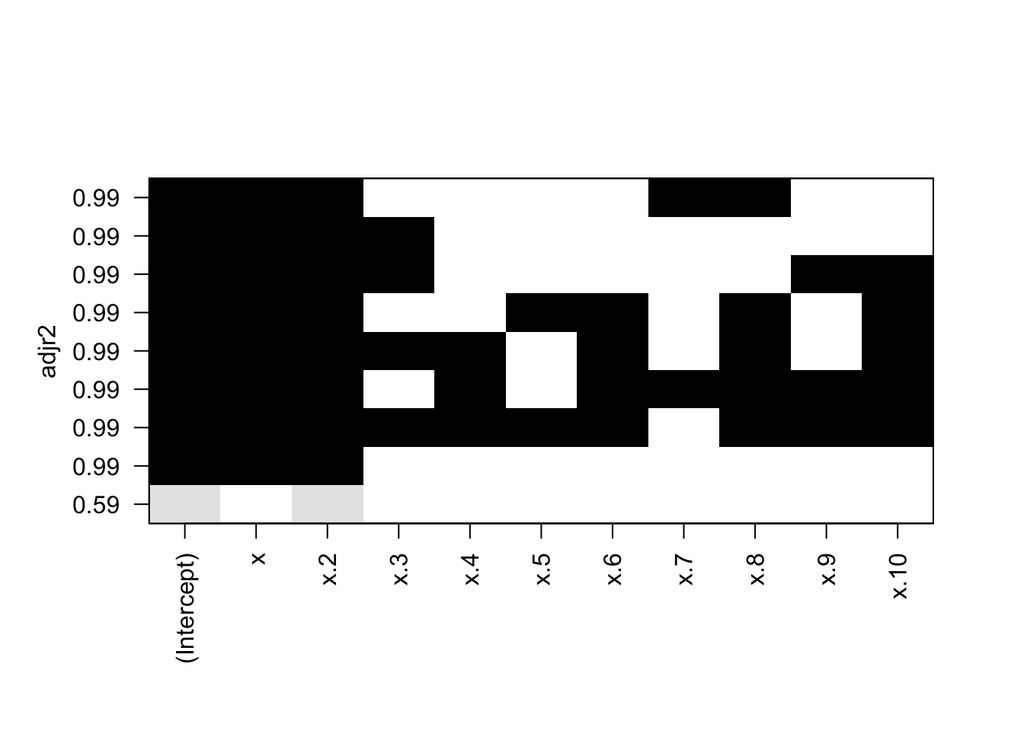

```r
plot(regfit.full,scale="adjr2")
```

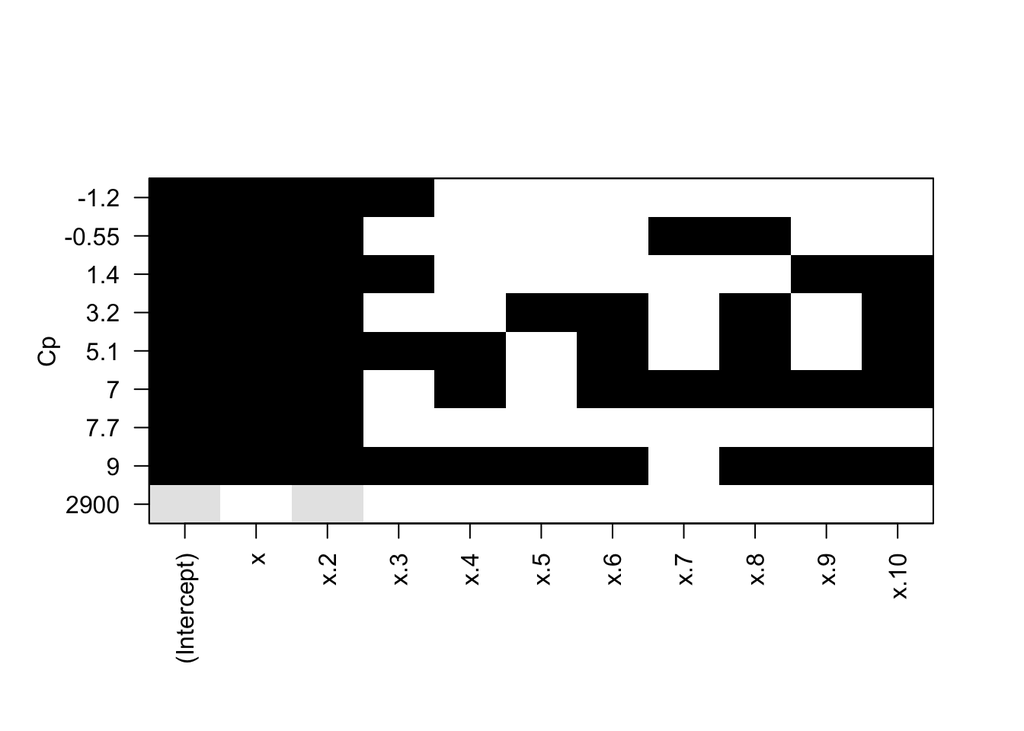

```r
plot(regfit.full,scale="Cp")
```

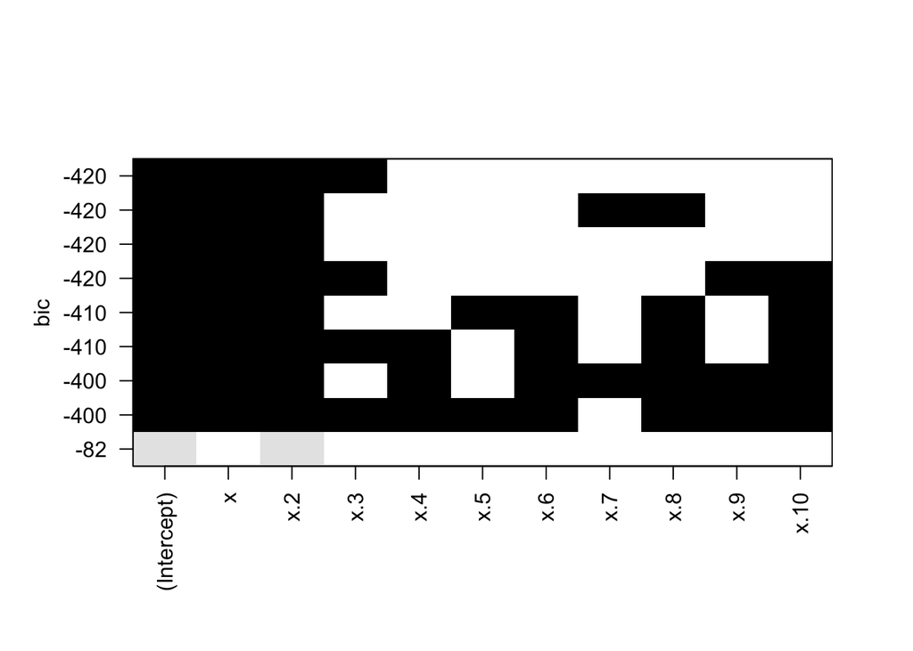

```r
plot(regfit.full,scale="bic")
```

```r
coefficients(regfit.full, id=3)
```

```
## (Intercept)           x         x.2         x.3
##    3.016267    5.104863   -5.064940    0.165374
```

**(d)**

```r
set.seed (1)
train=sample(c(TRUE,FALSE),nrow(all),rep=TRUE)
test=(!train)
regfit.fwd=regsubsets(y~.,data=all[train,],nvmax=9,method="forward")
test.mat=model.matrix(y~.,data=all[test,])
fwd.val.errors=rep(NA,9)
for(i in 1:9){
  coefi=coef(regfit.fwd,id=i)
  pred=test.mat[,names(coefi)]%*%coefi
  fwd.val.errors[i]=mean((all$y[test]-pred)^2)
}
which.min(fwd.val.errors)
```

```
## [1] 2
```

```r
regfit.bwd=regsubsets(y~.,data=all[train,],nvmax=9,method="backward")
test.mat=model.matrix(y~.,data=all[test,])
bwd.val.errors=rep(NA,9)
for(i in 1:9){
  coefi=coef(regfit.bwd,id=i)
  pred=test.mat[,names(coefi)]%*%coefi
  bwd.val.errors[i]=mean((all$y[test]-pred)^2)
}
which.min(bwd.val.errors)
```

```
## [1] 2
```

```r
regfit.full=regsubsets(y~.,data=all,nvmax=9,method="forward")
reg.summary=summary(regfit.full)
coef(regfit.full,3)
```

```
## (Intercept)           x         x.2         x.3
##    3.016267    5.104863   -5.064940    0.165374
```

```r
regfit.full=regsubsets(y~.,data=all,nvmax=9,method="backward")
reg.summary=summary(regfit.full)
coef(regfit.full,3)
```

```
## (Intercept)           x         x.2         x.5
##  3.02707102  5.33149452 -5.09803916  0.01937042
```

**(e)**

```r
library(glmnet)
```

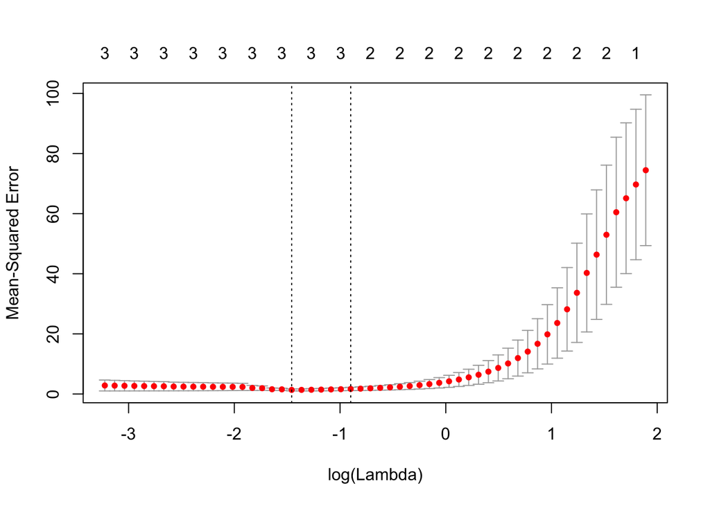

```r
set.seed(1)
dat.mat=model.matrix(y~poly(x,10,raw=T),data=all)[,-1]
cv.out=cv.glmnet(dat.mat,y,alpha=1)
plot(cv.out)
```

```r
bestlam=cv.out$lambda.min
bestlam
```

```
## [1] 0.232835
```

```r
lasso.mod=glmnet(dat.mat,y,alpha=1,lambda=bestlam)
coef(lasso.mod)
```

```
## 11 x 1 sparse Matrix of class "dgCMatrix"
##                                 s0
## (Intercept)             2.81386281
## poly(x, 10, raw = T)1   5.11990162
## poly(x, 10, raw = T)2  -4.83803910
## poly(x, 10, raw = T)3   0.07495281
## poly(x, 10, raw = T)4   .
## poly(x, 10, raw = T)5   .
## poly(x, 10, raw = T)6   .
## poly(x, 10, raw = T)7   .
## poly(x, 10, raw = T)8   .
## poly(x, 10, raw = T)9   .
## poly(x, 10, raw = T)10  .
```

**9.**